# MAS2908 - Practical 06 (Solutions)

Clement Lee

Semester 2, 2025/2026

# 1 Introduction

This practical reinforces Chapter 7 of the notes, exploring two complementary approaches to the same visualisation: manipulating data explicitly with `dplyr`, or using built-in functions in `ggplot2`. You will practice:

- Counting with `dplyr::count()` vs letting `geom_bar()` count automatically
- Subsetting data with `filter()`, `scale_*_continuous()`, and `coord_cartesian()`
- Overlaying group summaries using `stat_summary()` vs a separate data frame
- Overlaying a density curve on a histogram using `after_stat(density)`
- Diagnosing normality with Q-Q plots

Throughout this practical we use the built-in `mpg` and `mtcars` datasets.

# 2 Bar charts and counting

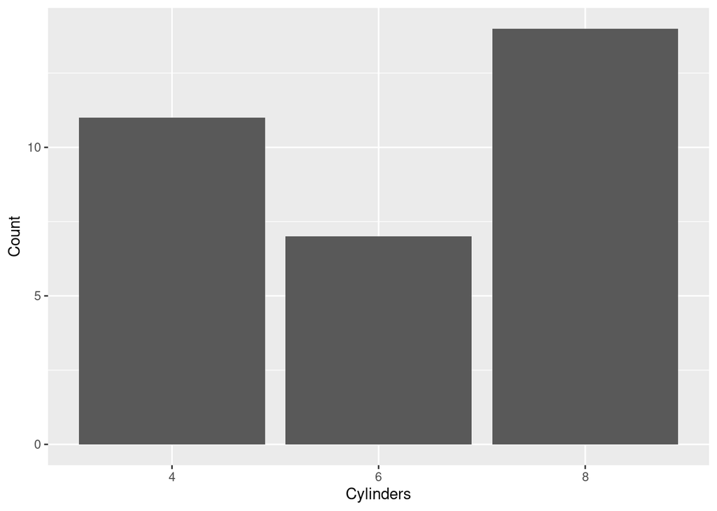

```r
# geom_bar() automatically counts from raw data
ggplot(mtcars, aes(x = factor(cyl))) +
  geom_bar() +
  labs(x = "Cylinders", y = "Count")
```

1. Using `mtcars`, create a bar chart of `gear` (number of gears) using `geom_bar()`. Add appropriate axis labels.

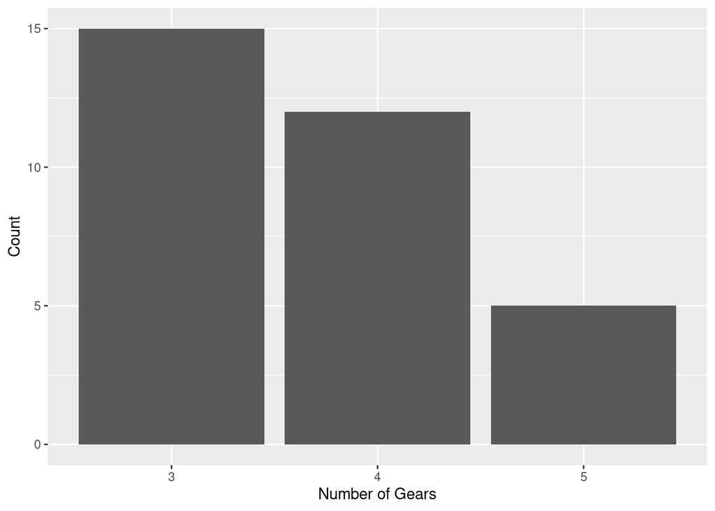

   ```r
   ggplot(mtcars, aes(x = factor(gear))) +
     geom_bar() +
     labs(x = "Number of Gears", y = "Count")
   ```

2. Use `count()` to compute the number of cars with each value of `gear` from `mtcars`. Store this as `gear_counts`, then recreate the same bar chart using `geom_col()`. Verify the two charts look identical.

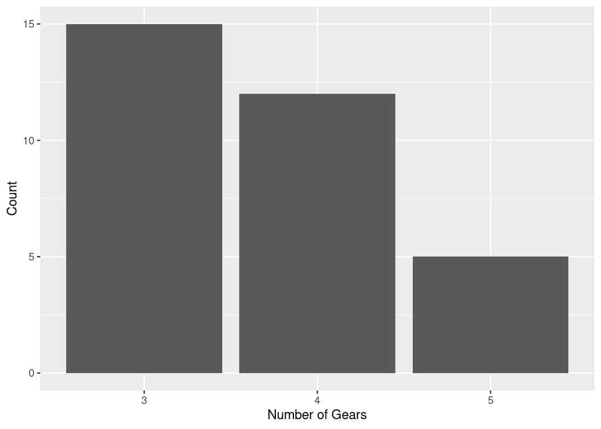

   ```r
   gear_counts <- mtcars |>
     count(gear) |>
     rename(gears = gear, count = n)

   ggplot(gear_counts, aes(x = factor(gears), y = count)) +
     geom_col() +
     labs(x = "Number of Gears", y = "Count")
   ```

3. What happens if you supply `gear_counts` to `geom_bar()` without `stat = "identity"`? Demonstrate this and explain why the bars all have height 1.

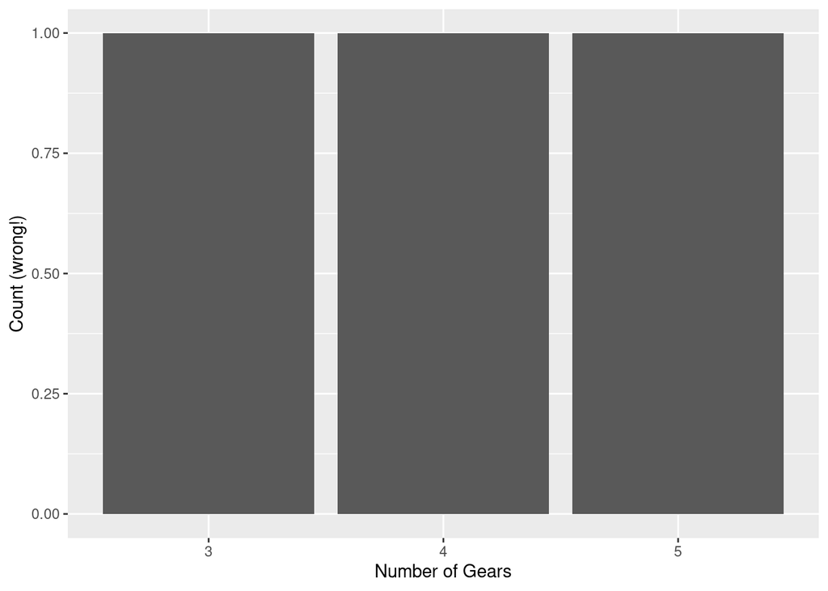

   ```r
   ggplot(gear_counts, aes(x = factor(gears))) +
     geom_bar() +
     labs(x = "Number of Gears", y = "Count (wrong!)")
   ```

   `geom_bar()` counts the rows of the data frame passed to it. `gear_counts` has one row per gear value (3 rows), so each bar has height 1. To use pre-computed counts, switch to `geom_col()`, or add `stat = 'identity'` to `geom_bar()`.
4. Using `mpg`, create a horizontal bar chart showing the count of cars for each `manufacturer`. Which manufacturer has the most cars in the dataset?

   **Hint**: Map `manufacturer` to the `y` aesthetic (not `x`) for a horizontal chart.

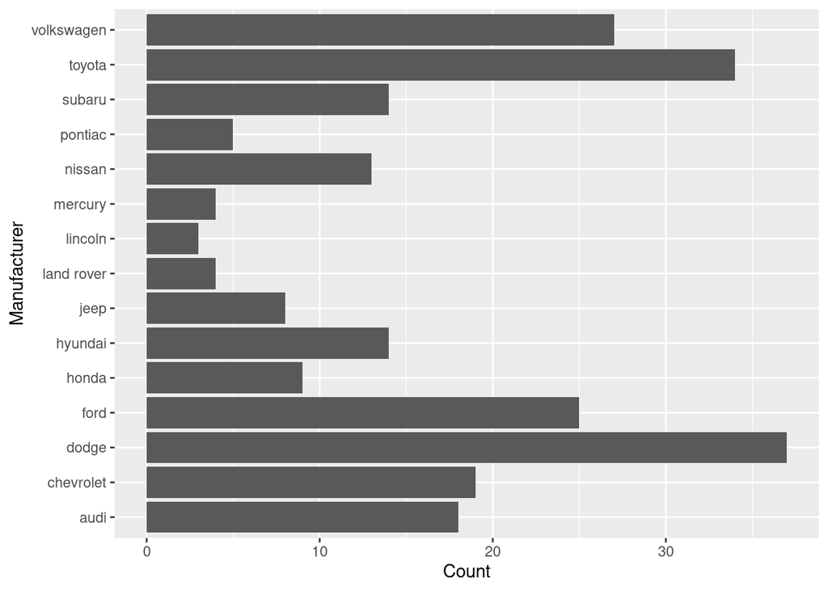

   ```r
   ggplot(mpg, aes(y = manufacturer)) +
     geom_bar() +
     labs(x = "Count", y = "Manufacturer")
   ```

5. The following code creates a pre-counted summary. Use `geom_col()` to create a bar chart, ordered from most to fewest cars per class, displayed horizontally.

   **Hint**: Use `reorder(class, n)` inside `aes()` to order the bars.

   ```r
   class_summary <- mpg |>
     count(class) |>
     arrange(desc(n))
   class_summary
   ```

   ```
   ## # A tibble: 7 × 2
   ##   class          n
   ##   <chr>      <int>
   ## 1 suv           62
   ## 2 compact       47
   ## 3 midsize       41
   ## 4 subcompact    35
   ## 5 pickup        33
   ## 6 minivan       11
   ## 7 2seater        5
   ```

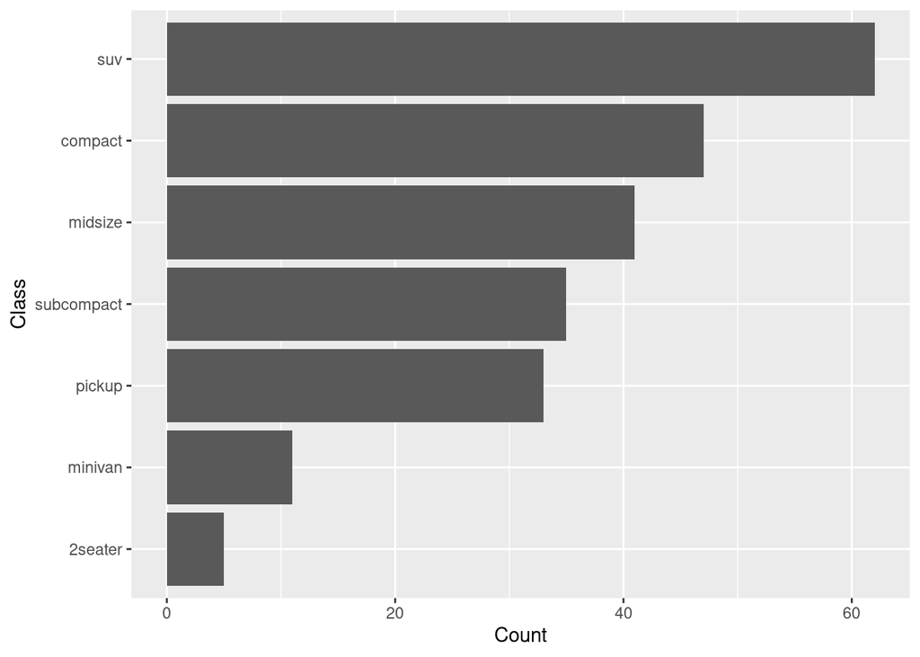

   ```r
   ggplot(class_summary, aes(x = reorder(class, n), y = n)) +
     geom_col() +
     coord_flip() +
     labs(x = "Class", y = "Count")
   ```

# 3 Subsetting data

All three approaches below produce visually similar plots of `displ` vs `hwy` restricted to displacement values between 2 and 6.

6. Create the three versions of the plot using: (a) `filter()`, (b) `scale_x_continuous(limits = c(2, 6))`, (c) `coord_cartesian(xlim = c(2, 6))`.

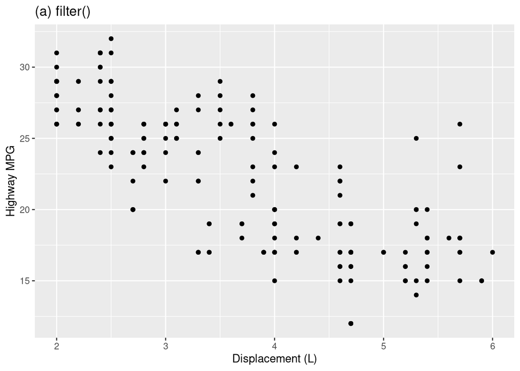

   ```r
   mpg |>
     filter(displ >= 2, displ <= 6) |>
     ggplot(aes(x = displ, y = hwy)) +
     geom_point() +
     labs(x = "Displacement (L)", y = "Highway MPG",
          title = "(a) filter()")
   ```

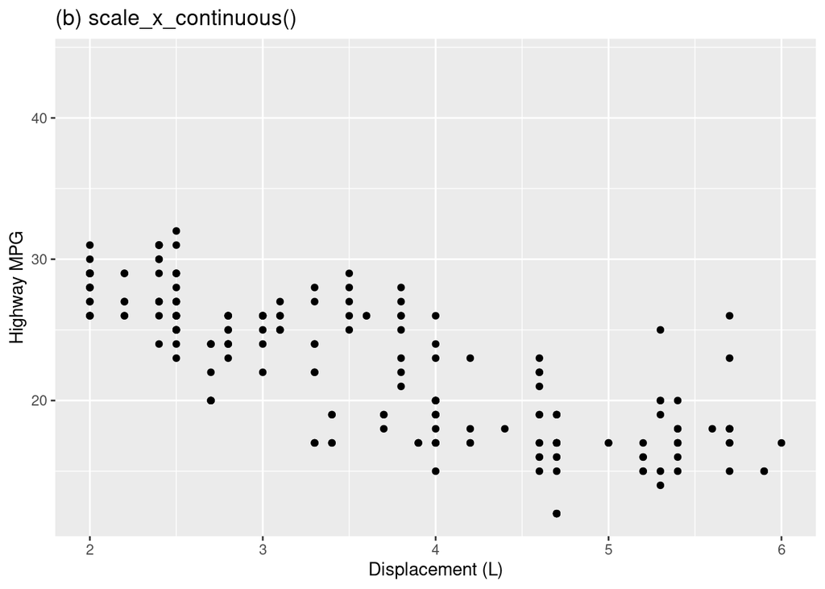

   ```r
   ggplot(mpg, aes(x = displ, y = hwy)) +
     geom_point() +
     scale_x_continuous(limits = c(2, 6)) +
     labs(x = "Displacement (L)", y = "Highway MPG",
          title = "(b) scale_x_continuous()")
   ```

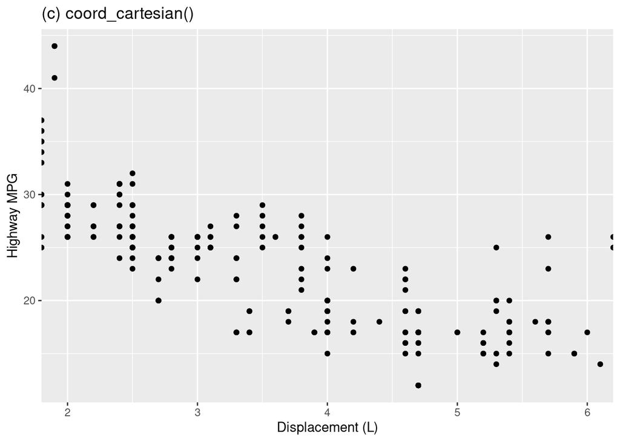

   ```r
   ggplot(mpg, aes(x = displ, y = hwy)) +
     geom_point() +
     coord_cartesian(xlim = c(2, 6)) +
     labs(x = "Displacement (L)", y = "Highway MPG",
          title = "(c) coord_cartesian()")
   ```

7. Add `geom_smooth()` to each of the three plots from Q6. Do the smooth lines differ between (a) and (c)? Why?

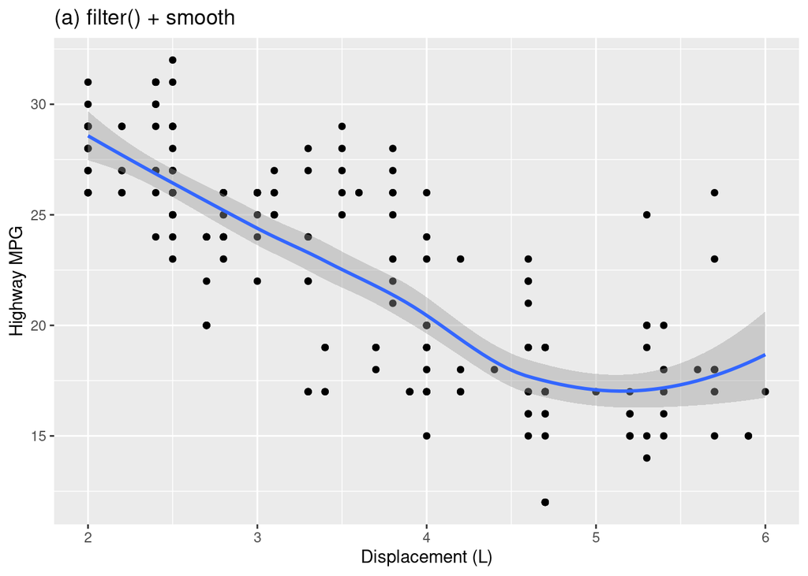

   ```r
   mpg |>
     filter(displ >= 2, displ <= 6) |>
     ggplot(aes(x = displ, y = hwy)) +
     geom_point() +
     geom_smooth() +
     labs(x = "Displacement (L)", y = "Highway MPG",
          title = "(a) filter() + smooth")
   ```

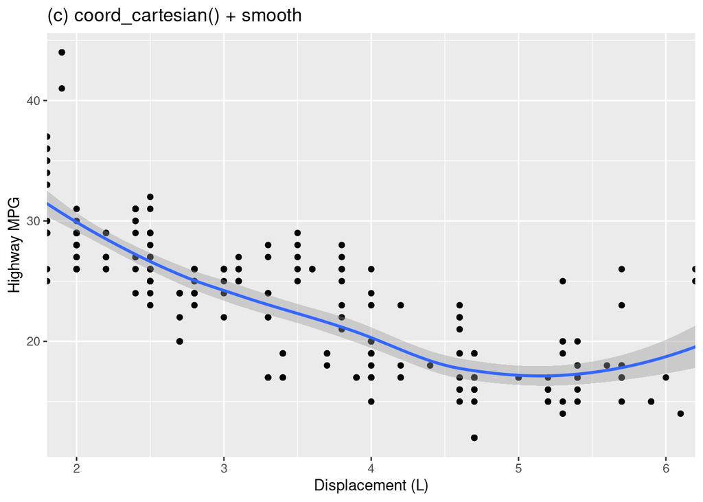

   ```r
   ggplot(mpg, aes(x = displ, y = hwy)) +
     geom_point() +
     geom_smooth() +
     coord_cartesian(xlim = c(2, 6)) +
     labs(x = "Displacement (L)", y = "Highway MPG",
          title = "(c) coord_cartesian() + smooth")
   ```

   The smooth lines can differ. With `filter()`, `geom_smooth()` is fitted using only the subset (displacement between 2 and 6). With `coord_cartesian()`, the smooth is fitted using *all* observations and then zoomed into. The smooth from `coord_cartesian()` is informed by the full data range, which can change the shape of the curve near the edges.

# 4 Overlaying group summaries

In the notes (Section on `stat_summary()`), we saw that the same plot can be produced by either computing group means with `dplyr` first, or letting `stat_summary()` compute them during plotting.

8. Using `stat_summary()`, create a bar chart showing the **mean** highway MPG (`hwy`) for each vehicle `class` in `mpg`. Do not pre-compute the means with `dplyr`.

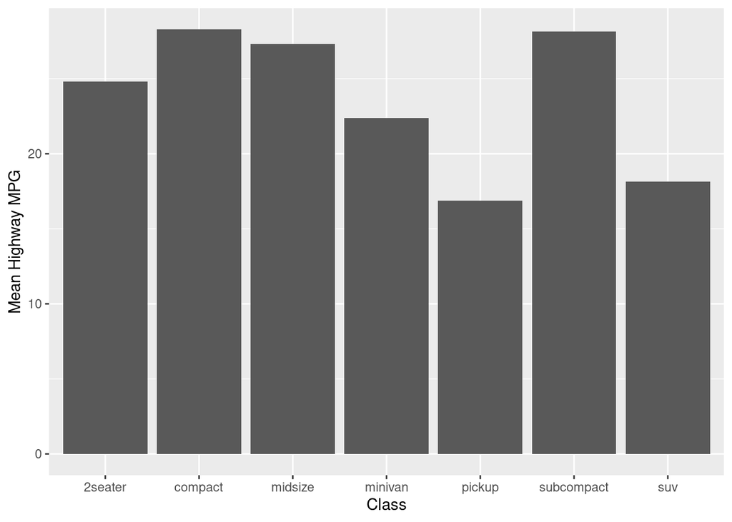

   ```r
   ggplot(mpg, aes(x = class, y = hwy)) +
     stat_summary(fun = mean, geom = "bar") +
     labs(x = "Class", y = "Mean Highway MPG")
   ```

9. Using `mpg`, create a jitter plot of `displ` ($y$-axis) by `drv` ($x$-axis). Overlay the group means as large red points using `stat_summary(fun = mean, geom = "point")`.

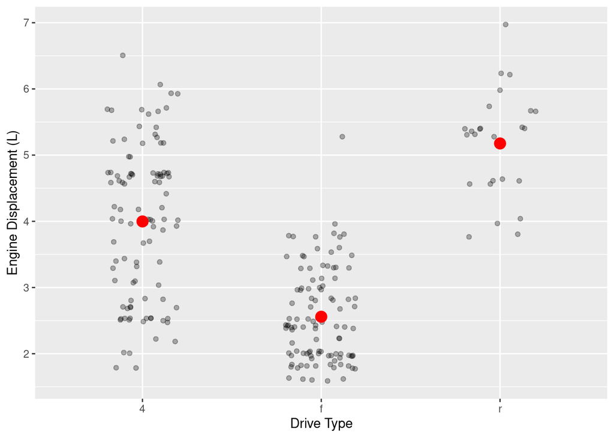

   ```r
   ggplot(mpg, aes(x = drv, y = displ)) +
     geom_jitter(alpha = 0.3, width = 0.2) +
     stat_summary(fun = mean, geom = "point",
                  colour = "red", size = 4) +
     labs(x = "Drive Type", y = "Engine Displacement (L)")
   ```

10. Achieve the same result as Q9 using `group_by()` and `summarise()` to compute the group means first, then adding a second `geom_point()` layer with the summary data frame. Do the red points appear in the same positions?

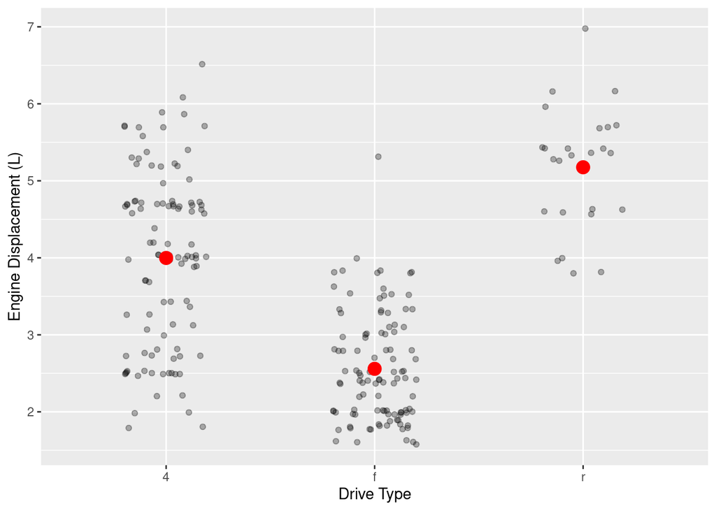

    ```r
    drv_means <- mpg |>
      group_by(drv) |>
      summarise(mean_displ = mean(displ))

    ggplot() +
      geom_jitter(data = mpg,
                  aes(x = drv, y = displ),
                  alpha = 0.3, width = 0.2) +
      geom_point(data = drv_means,
                 aes(x = drv, y = mean_displ),
                 colour = "red", size = 4) +
      labs(x = "Drive Type", y = "Engine Displacement (L)")
    ```

    Yes — the red points appear in exactly the same positions. Both approaches compute the same group means; they differ only in *when*: `stat_summary()` does it during plotting, while `group_by()` + `summarise()` does it beforehand.
11. Which approach would you prefer if you also needed the group means in a separate summary table? Which would you prefer for a quick exploratory plot?

    If you need the group means elsewhere (e.g., in a table or for further analysis), the dplyr approach is better: you compute the summary once and can reuse it. For a quick exploratory plot where the summary is only needed for the visualisation, `stat_summary()` is cleaner and more concise.

# 5 Histogram with density overlay

12. Create a histogram of `displ` from `mpg` using `geom_histogram(binwidth = 0.5)`. Overlay `geom_density()` without any modification. Describe what you observe.

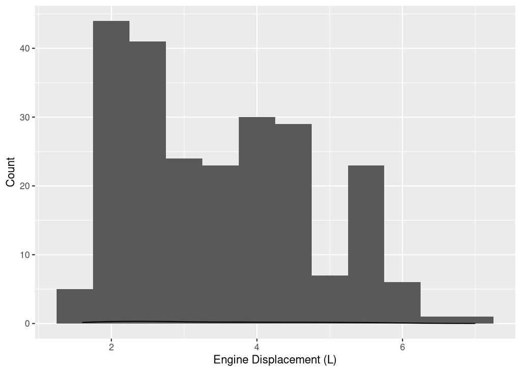

    ```r
    ggplot(mpg, aes(x = displ)) +
      geom_histogram(binwidth = 0.5) +
      geom_density() +
      labs(x = "Engine Displacement (L)", y = "Count")
    ```

    The density curve appears as a nearly flat line near zero. The histogram $y$-axis is in count units (up to around 40), while density values are much smaller (below 0.5). The two geoms are on completely different scales.
13. Fix the overlay from Q12 using `after_stat(density)`. Does the density curve now align with the histogram?

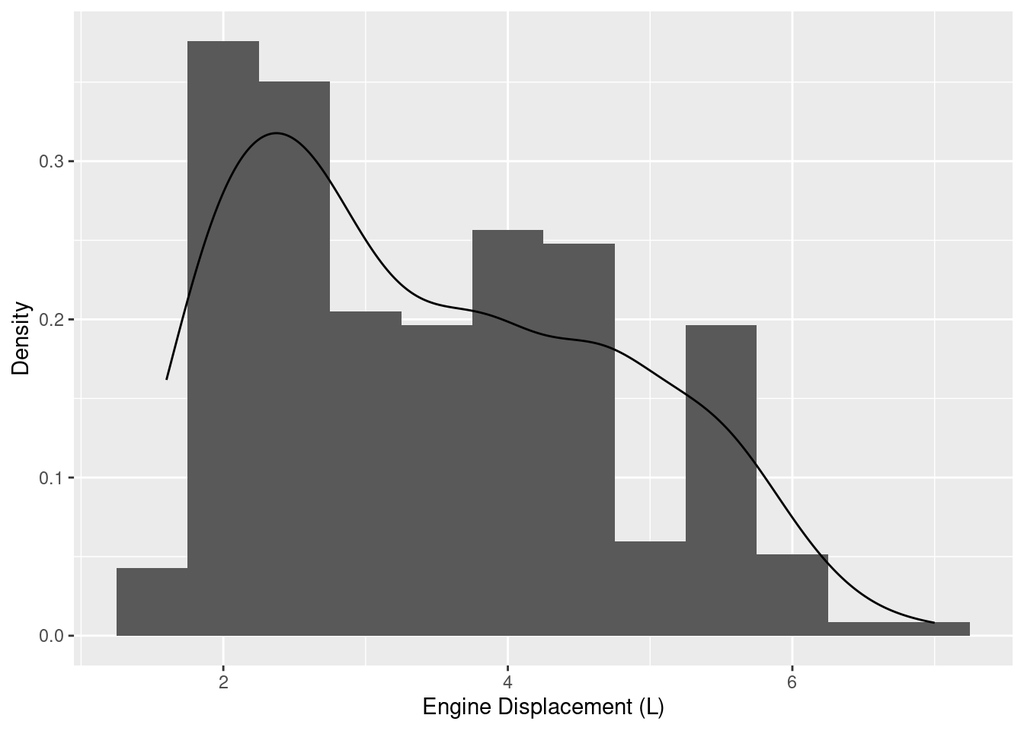

    ```r
    ggplot(mpg, aes(x = displ)) +
      geom_histogram(aes(y = after_stat(density)), binwidth = 0.5) +
      geom_density() +
      labs(x = "Engine Displacement (L)", y = "Density")
    ```

    Yes — with `after_stat(density)`, the histogram bars are rescaled to density units and the density curve now overlays them on the same scale.
14. Looking at the histogram + density from Q13, does `displ` appear approximately normally distributed? What features suggest it might not be?

# 6 Q-Q plots

15. Create a Q-Q plot of `hwy` (highway miles per gallon) from `mpg`. Does highway MPG appear normally distributed? Describe any departures from the reference line.

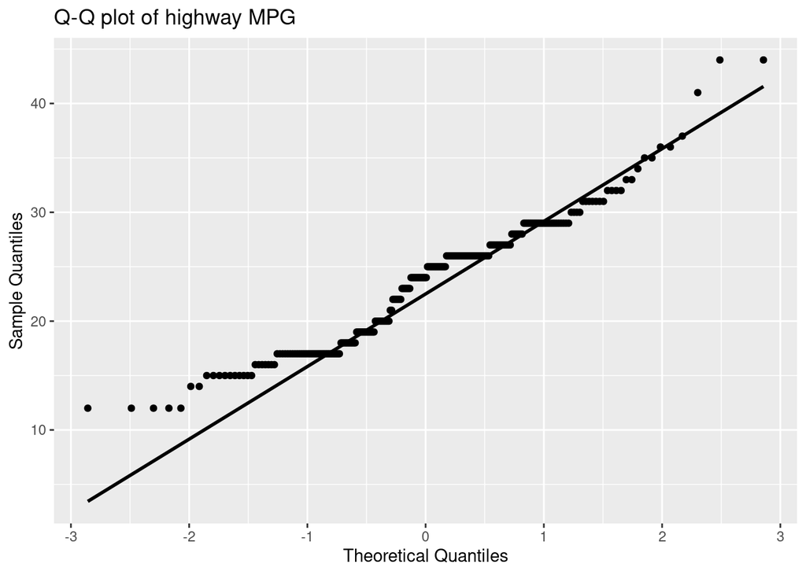

    ```r
    ggplot(mpg, aes(sample = hwy)) +
      geom_qq() +
      geom_qq_line(linewidth = 1) +
      labs(x = "Theoretical Quantiles", y = "Sample Quantiles",
           title = "Q-Q plot of highway MPG")
    ```

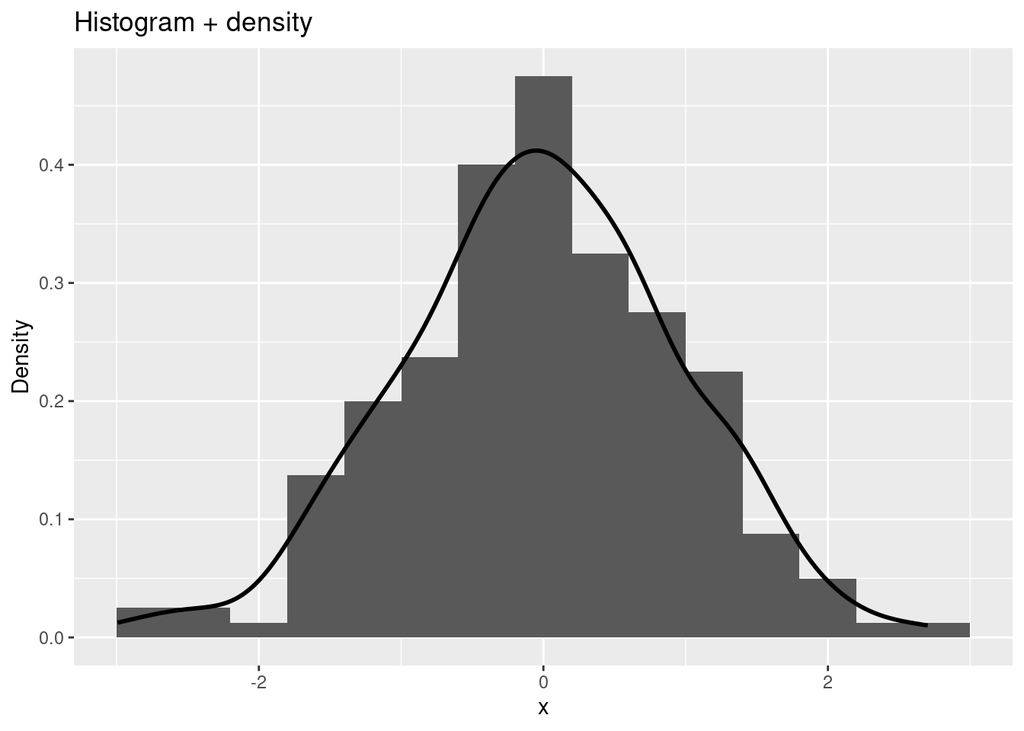

    ```r
    set.seed(42)
    sim_data <- data.frame(x = rnorm(200))

    ggplot(sim_data, aes(x = x)) +
      geom_histogram(aes(y = after_stat(density)), binwidth = 0.4) +
      geom_density(linewidth = 1) +
      labs(x = "x", y = "Density", title = "Histogram + density")
    ```

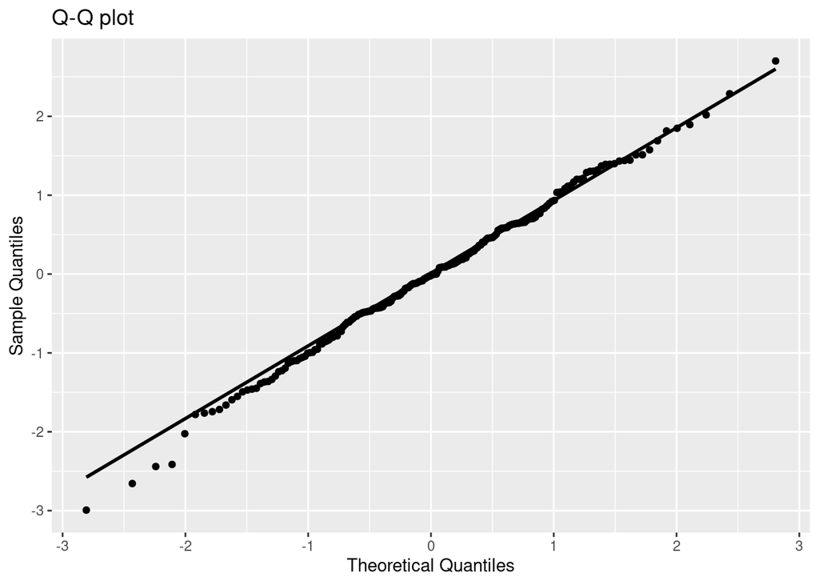

    ```r
    ggplot(sim_data, aes(sample = x)) +
      geom_qq() +
      geom_qq_line(linewidth = 1) +
      labs(x = "Theoretical Quantiles", y = "Sample Quantiles",
           title = "Q-Q plot")
    ```

# 7 Summary: This practical

| Visualisation | Approach A: dplyr first | Approach B: ggplot2 built-in |
| --- | --- | --- |
| Bar chart of counts | `count()` $\to$ `geom_col()` | `geom_bar()` |
| Subset a scatterplot | `filter()` | `scale_*_continuous(limits=)` or `coord_cartesian()` |
| Raw data $+$ group means | `group_by()` $+$ `summarise()` | `stat_summary(fun = mean, ...)` |
| Histogram $+$ density | *(not straightforward)* | `geom_histogram(aes(y = after_stat(density)))` $+$ `geom_density()` |
| Q-Q plot | *(not available)* | `geom_qq()` $+$ `geom_qq_line()` |

# 8 Checklist

By completing Practicals 1–6, you should be able to create **polished and informative visualisations** and understand the data manipulation steps behind them. Use this checklist to review your understanding.

## 8.1 Basic geoms (Chapter 3, Practical 3)

- Choose appropriate geoms for your data type:
  - Scatterplots with `geom_point()` for two continuous variables
  - Line plots with `geom_line()` for trends over time
  - Bar charts with `geom_bar()` for counts, `geom_col()` for values
  - Histograms with `geom_histogram()` for distributions
  - Boxplots with `geom_boxplot()` for comparing distributions
- Combine multiple geoms in one plot (e.g., points + smooth line)
- Understand the difference between `colour` (outlines/points) and `fill` (interiors)

## 8.2 Colours (Chapter 4, Practical 4)

- Map variables to colour using `aes(colour = ...)` or `aes(fill = ...)`
- Choose appropriate colour scales:
  - Discrete: `scale_*_brewer()`, `scale_*_viridis_d()`
  - Continuous: `scale_*_gradient()`, `scale_*_viridis_c()`
  - Binned: `scale_*_fermenter()`, `scale_*_viridis_b()`
- Use colourblind-friendly palettes (viridis, Okabe-Ito)
- Recognise errors from mismatched scale types

## 8.3 Other scales (Chapter 5, Practical 4)

- Map variables to shape, size, alpha, and linetype
- Use redundant encoding (e.g., colour + shape) for accessibility
- Transform axes with `scale_x_log10()`, `scale_y_sqrt()`, etc.
- Control axis limits with `scale_*_continuous(limits = ...)`

## 8.4 Reading external data (`readr` and `readxl`) (Practical 4)

- Read CSV files with `readr::read_csv()`
- Read Excel files with `readxl::read_excel()`
- Handle common arguments: `skip`, `col_names`, `sheet`, `range`

| Function | Package | File type |
| --- | --- | --- |
| `read_csv()` | `readr` | Comma-separated values (.csv) |
| `read_excel()` | `readxl` | Excel workbook (.xlsx / .xls) |

```r
library(readr)
data <- read_csv("myfile.csv")
```

## 8.5 Cosmetics (Chapter 6, Practical 5)

- Fix legend titles with `labs(colour = "Nice Title")`
- Avoid scientific notation with `scales::label_comma()`
- Control axis breaks with `scale_*_continuous(breaks = ...)`
- Position legends with `theme(legend.position = ...)`
- Apply built-in themes: `theme_bw()`, `theme_minimal()`, `theme_classic()`

## 8.6 Building plots incrementally (Practical 5)

- Save plots as objects: `p <- ggplot(...) + ...`
- Add layers or scales later: `p + theme_bw()`
- Use `last_plot()` for interactive exploration (console only, not in R Markdown)

## 8.7 Data manipulation with `dplyr` (Chapter 7, Practical 6)

- Know the six key `dplyr` functions: `filter()`, `mutate()`, `count()`, `arrange()`, `group_by()`, `summarise()`
- Understand `geom_bar()` (counts automatically) vs `geom_col()` (uses values as-is)
- Compare `filter()`, `scale_*_continuous(limits=)`, and `coord_cartesian()` for subsetting data
- Overlay group summaries on raw data using `stat_summary(fun = ...)` or a separate data frame
- Overlay a density curve on a histogram using `after_stat(density)`
- Create Q-Q plots using `geom_qq()` and `geom_qq_line()`

| Function | What it does | Closest Excel operation |
| --- | --- | --- |
| `filter()` | Keep rows matching a condition | AutoFilter |
| `mutate()` | Create or modify columns | Adding a formula to a new column |
| `count()` | Count occurrences of each value | COUNTIF, or a pivot table |
| `arrange()` | Sort rows | Data $\to$ Sort |
| `group_by()` | Group data for subsequent operations | Pivot table grouping |
| `summarise()` | Compute summary statistics per group | Pivot table values |

**Important**: Always load `dplyr` before using these functions. If you don’t, R may silently use a different `filter()` from the `stats` package, which behaves completely differently and causes confusing errors.

```r
library(dplyr)  # Load first!

data |>
  filter(year >= 2000) |>
  mutate(rate = count / total * 100) |>
  ggplot(aes(x = year, y = rate)) +
  geom_line()
```

## 8.8 The data science pipeline

Data visualisation is one step in a larger workflow. A polished, informative plot requires:

**Choosing the right geom(s)** for the data and message, and working through the pipeline:

1. **Read** data from files (`readr`, `readxl`)
2. **Clean and transform** data (`dplyr`, `tidyr`)
3. **Visualise** with `ggplot2`

For each visualisation, also ensure:

- **Clear axis labels** with units where applicable
- **Informative legend title** (not `factor(x)`)
- **Colourblind-friendly palette** (e.g., viridis)
- **Readable scales** (no unnecessary scientific notation)
- **Clean theme** (e.g., `theme_minimal()`)
- **Title or caption** if needed for context

Mastering data visualisation means mastering the entire pipeline, not just the plotting step.